# STAT 184 Final Project

Drew Eddy and Seth Johnson

## Research Question

Our overarching research question for our project was to determine which variables about a movie have the highest positive correlation with its imbd score. An imdb score is a common measure created as an aggregate score of movie critic reviews, so the higher the imdb score, the better reviews that movie has recieved. To answer our research question, we explored several variables in our movie dataset individually, picked those with the most promise, and then charted those selected variables together. In addition, we created a regression tree with said variables to show what choices a machine learning model would make to predict an imdb score.

## Front Matter

Here are the library packages we used

```r
#Libraries used
library(mosaic)
library(tidyverse)
library(DataComputing)
library(party)
library(rpart)
library(rpart.plot)
```

## Data Retrieval

Below is the code which reads in the 2 csv files used for this analysis, which are called “dataset_1_raw” and “dataset_2_raw” for now.

The first dataset we used is a csv file of 5000 Movies where each instance is a distict movie with additional info like director, budget, revenue, etc.

The Second dataset is a similar csv about Movies with additional columns like runtime and release year.

```r
# retrieving both csv datasets
dataset_1_raw = read_csv("movie_data.csv")
dataset_2_raw = read_csv("stat_2.csv")
```

Below are some lines to inspect both datasets using the head() R function. We used the head() functions to get a quick view of what an instance of each dataset looks like.

```r
dataset_1_raw %>%
  head(5)
```

| color | director_name | num_critic_for_reviews | duration | director_facebook_likes | actor_3_facebook_likes | actor_2_name | actor_1_facebook_likes | gross | genres | actor_1_name | movie_title | num_voted_users | cast_total_facebook_likes | actor_3_name | facenumber_in_poster | plot_keywords | movie_imdb_link | num_user_for_reviews | language | country | content_rating | budget | title_year | actor_2_facebook_likes | imdb_score | aspect_ratio | movie_facebook_likes |
| --- | --- | --- | --- | --- | --- | --- | --- | --- | --- | --- | --- | --- | --- | --- | --- | --- | --- | --- | --- | --- | --- | --- | --- | --- | --- | --- | --- |
| Color | James Cameron | 723 | 178 | 0 | 855 | Joel David Moore | 1000 | 760505847 | Action\|Adventure\|Fantasy\|Sci-Fi | CCH Pounder | Avatar | 886204 | 4834 | Wes Studi | 0 | avatar\|future\|marine\|native\|paraplegic | http://www.imdb.com/title/tt0499549/?ref_=fn_tt_tt_1 | 3054 | English | USA | PG-13 | 2.37e+08 | 2009 | 936 | 7.9 | 1.78 | 33000 |
| Color | Gore Verbinski | 302 | 169 | 563 | 1000 | Orlando Bloom | 40000 | 309404152 | Action\|Adventure\|Fantasy | Johnny Depp | Pirates of the Caribbean: At World's End | 471220 | 48350 | Jack Davenport | 0 | goddess\|marriage ceremony\|marriage proposal\|pirate\|singapore | http://www.imdb.com/title/tt0449088/?ref_=fn_tt_tt_1 | 1238 | English | USA | PG-13 | 3.00e+08 | 2007 | 5000 | 7.1 | 2.35 | 0 |
| Color | Sam Mendes | 602 | 148 | 0 | 161 | Rory Kinnear | 11000 | 200074175 | Action\|Adventure\|Thriller | Christoph Waltz | Spectre | 275868 | 11700 | Stephanie Sigman | 1 | bomb\|espionage\|sequel\|spy\|terrorist | http://www.imdb.com/title/tt2379713/?ref_=fn_tt_tt_1 | 994 | English | UK | PG-13 | 2.45e+08 | 2015 | 393 | 6.8 | 2.35 | 85000 |
| Color | Christopher Nolan | 813 | 164 | 22000 | 23000 | Christian Bale | 27000 | 448130642 | Action\|Thriller | Tom Hardy | The Dark Knight Rises | 1144337 | 106759 | Joseph Gordon-Levitt | 0 | deception\|imprisonment\|lawlessness\|police officer\|terrorist plot | http://www.imdb.com/title/tt1345836/?ref_=fn_tt_tt_1 | 2701 | English | USA | PG-13 | 2.50e+08 | 2012 | 23000 | 8.5 | 2.35 | 164000 |
| NA | Doug Walker | NA | NA | 131 | NA | Rob Walker | 131 | NA | Documentary | Doug Walker | Star Wars: Episode VII - The Force Awakens | 8 | 143 | NA | 0 | NA | http://www.imdb.com/title/tt5289954/?ref_=fn_tt_tt_1 | NA | NA | NA | NA | NA | NA | 12 | 7.1 | NA | 0 |

Since the second dataset (dataset_2_raw) contains several variables with long string values, only useful variables we wanted were selected for a quick view of the data.

```r
dataset_2_raw %>%
  select(original_title, revenue, id, genres) %>%
  head(5)
```

| original_title | revenue | id | genres |
| --- | --- | --- | --- |
| Avatar | 2787965087 | 19995 | [{"id": 28, "name": "Action"}, {"id": 12, "name": "Adventure"}, {"id": 14, "name": "Fantasy"}, {"id": 878, "name": "Science Fiction"}] |
| Pirates of the Caribbean: At World's End | 961000000 | 285 | [{"id": 12, "name": "Adventure"}, {"id": 14, "name": "Fantasy"}, {"id": 28, "name": "Action"}] |
| Spectre | 880674609 | 206647 | [{"id": 28, "name": "Action"}, {"id": 12, "name": "Adventure"}, {"id": 80, "name": "Crime"}] |
| The Dark Knight Rises | 1084939099 | 49026 | [{"id": 28, "name": "Action"}, {"id": 80, "name": "Crime"}, {"id": 18, "name": "Drama"}, {"id": 53, "name": "Thriller"}] |
| John Carter | 284139100 | 49529 | [{"id": 28, "name": "Action"}, {"id": 12, "name": "Adventure"}, {"id": 878, "name": "Science Fiction"}] |

The point of the second dataset is to supplement the first so here we alter the second dataset by selecting only the few variables we need and renaming the dataset dataset_2_updated. Also use the head() function to get a quick view of what the new dataset looks like.

```r
dataset_2_updated <-
  dataset_2_raw %>%
    select(original_title, revenue, release_date, original_language)
dataset_2_updated %>%
  head(5)
```

| original_title | revenue | release_date | original_language |
| --- | --- | --- | --- |
| Avatar | 2787965087 | 12/10/2009 | en |
| Pirates of the Caribbean: At World's End | 961000000 | 5/19/2007 | en |
| Spectre | 880674609 | 10/26/2015 | en |
| The Dark Knight Rises | 1084939099 | 7/16/2012 | en |
| John Carter | 284139100 | 3/7/2012 | en |

```r
dataset_1_raw<-
  dataset_1_raw %>%
    select(movie_title, imdb_score, director_name, content_rating, title_year, actor_1_name, actor_2_name, actor_3_name, genres, duration, num_critic_for_reviews)
```

Here we remove variables from our main dataset by selecting all variables we want to remain.

```r
#movie_data is the final combined dataset of the two previous datasets
movie_data<-
  dataset_1_raw %>%
    left_join(dataset_2_updated, by = c("movie_title"= "original_title"))
movie_data %>%
  head(5)
```

| movie_title | imdb_score | director_name | content_rating | title_year | actor_1_name | actor_2_name | actor_3_name | genres | duration | num_critic_for_reviews | revenue | release_date | original_language |
| --- | --- | --- | --- | --- | --- | --- | --- | --- | --- | --- | --- | --- | --- |
| Avatar | 7.9 | James Cameron | PG-13 | 2009 | CCH Pounder | Joel David Moore | Wes Studi | Action\|Adventure\|Fantasy\|Sci-Fi | 178 | 723 | 2787965087 | 12/10/2009 | en |
| Pirates of the Caribbean: At World's End | 7.1 | Gore Verbinski | PG-13 | 2007 | Johnny Depp | Orlando Bloom | Jack Davenport | Action\|Adventure\|Fantasy | 169 | 302 | 961000000 | 5/19/2007 | en |
| Spectre | 6.8 | Sam Mendes | PG-13 | 2015 | Christoph Waltz | Rory Kinnear | Stephanie Sigman | Action\|Adventure\|Thriller | 148 | 602 | 880674609 | 10/26/2015 | en |
| The Dark Knight Rises | 8.5 | Christopher Nolan | PG-13 | 2012 | Tom Hardy | Christian Bale | Joseph Gordon-Levitt | Action\|Thriller | 164 | 813 | 1084939099 | 7/16/2012 | en |
| Star Wars: Episode VII - The Force Awakens | 7.1 | Doug Walker | NA | NA | Doug Walker | Rob Walker | NA | Documentary | NA | NA | NA | NA | NA |

Above we finally join the relevant information from dataset_2_updated to the main dataset (dataset_1_raw) to get a complete dataset which we will use from now on (called movie_data)

## Basic Summary Statistics and Overview

Since the research question asks what factors-in to top level imdb scores, below is a view of the top 25 movies titles based of their imbd score

```r
movie_data %>%
  select(movie_title, imdb_score) %>%
  arrange(desc(imdb_score)) %>%
  head(25)
```

| movie_title | imdb_score |
| --- | --- |
| Towering Inferno | 9.5 |
| The Shawshank Redemption | 9.3 |
| The Godfather | 9.2 |
| Dekalog | 9.1 |
| Dekalog | 9.1 |
| Kickboxer: Vengeance | 9.1 |
| The Dark Knight | 9.0 |
| The Godfather: Part II | 9.0 |
| Fargo | 9.0 |
| The Lord of the Rings: The Return of the King | 8.9 |

[output cut: 15 more lines]

Above we can see that we have a duplicate movie in the database, to remove duplicates we used the distinct() function below (the movie ‘Towering Inferno’ was also removed because the imdb_score was inaccurate). After these cases are removed, the result top 25 movies is followed

```r
movie_data <- movie_data %>%
  distinct(movie_title, .keep_all = TRUE) %>%
  filter(movie_title != 'Towering Inferno')
movie_data %>%
  select(movie_title, imdb_score) %>%
  arrange(desc(imdb_score)) %>%
  head(25)
```

| movie_title | imdb_score |
| --- | --- |
| The Shawshank Redemption | 9.3 |
| The Godfather | 9.2 |
| Dekalog | 9.1 |
| Kickboxer: Vengeance | 9.1 |
| The Dark Knight | 9.0 |
| The Godfather: Part II | 9.0 |
| Fargo | 9.0 |
| The Lord of the Rings: The Return of the King | 8.9 |
| Schindler's List | 8.9 |
| Pulp Fiction | 8.9 |

[output cut: 15 more lines]

## The Influence of the Director

One factor that may result in a movie recieving a high imdb score is the director. Below is a view of that data that shows which directors (top25) have the highest imbd score on average for their movies and how many movies they have directed

```r
movie_data%>%
  group_by(director_name) %>%
  summarise(average_imdb_score = mean(imdb_score), number_of_movies = n()) %>%
  arrange(desc(average_imdb_score)) %>%
  head(25)
```

| director_name | average_imdb_score | number_of_movies |
| --- | --- | --- |
| Cary Bell | 8.700 | 1 |
| Mitchell Altieri | 8.700 | 1 |
| Sadyk Sher-Niyaz | 8.700 | 1 |
| Charles Chaplin | 8.600 | 1 |
| Mike Mayhall | 8.600 | 1 |
| Damien Chazelle | 8.500 | 1 |
| Majid Majidi | 8.500 | 1 |
| Raja Menon | 8.500 | 1 |
| Ron Fricke | 8.500 | 1 |
| Sergio Leone | 8.475 | 4 |

[output cut: 15 more lines]

It seems from the above view that directors who’ve only directed one movie do well for imdb_scores, to explore this further, below is a plot showing directors charted by the number of movies they’ve directed and imdb scores

```r
director_stat<-
  movie_data%>%
    group_by(director_name) %>%
    summarise(average_imdb_score = mean(imdb_score), number_of_movies = n()) %>%
    arrange(desc(average_imdb_score))
```

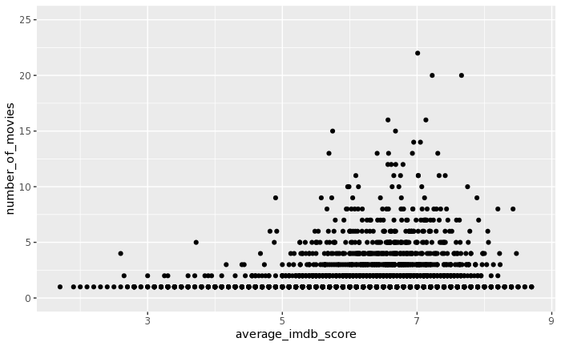

```r
ggplot(data = director_stat, aes(x = average_imdb_score, y = number_of_movies))+
  geom_point(data = director_stat)+ ylim(0, 25)
```

## Does the Content Rating influence imdb score

Another possible factor that might correlate with high or low imdb scores is a movie’s content rating, which classifies movies based on how mature its content is. To get a better idea of which content-ratings typically recieve what kind of score, below is a view that shows the average IMDB score by rating. Since we only wanted to include the standard film content rating (G, PG, PG-13, R, X, and Unrated), we used the grepl function and a regular expression to filter the others out.

```r
movie_data<-
  movie_data%>%
  mutate(content_rating = gsub(pattern = "Not Rated", replacement = "Unrated", content_rating))
```

```r
movie_data %>%
  select(content_rating, imdb_score) %>%
  group_by(content_rating) %>%
  summarise(average_imdb_score = mean(imdb_score), number_of_movies = n()) %>%
  filter(! grepl("TV|NC-17|Approved|Passed|GP|M", content_rating)) %>%
  arrange(desc(average_imdb_score))
```

| content_rating | average_imdb_score | number_of_movies |
| --- | --- | --- |
| Unrated | 6.712644 | 174 |
| G | 6.529464 | 112 |
| R | 6.522254 | 2067 |
| X | 6.416667 | 12 |
| NA | 6.393980 | 299 |
| PG | 6.288921 | 686 |
| PG-13 | 6.255209 | 1411 |

Below is a chart that shows this correlation better

```
Ignoring unknown parameters: binwidth, bins, pad
```

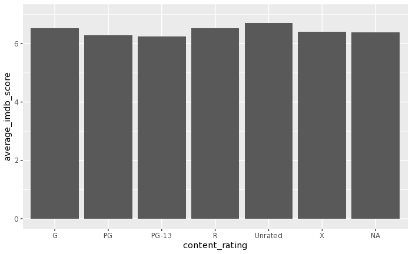

```r
movie_data %>%
  select(content_rating, imdb_score) %>%
  group_by(content_rating) %>%
  summarise(average_imdb_score = mean(imdb_score), number_of_movies = n()) %>%
  filter(! grepl("TV|NC-17|Approved|Passed|GP|M", content_rating))%>% #filters out several content ratings because there are not relevant
  arrange(desc(average_imdb_score)) %>%
  ggplot(aes(x = content_rating, y = average_imdb_score)) +
  geom_histogram(stat = "identity")+
  ylim(0, 7)
```

As we can see the content_rating doesn’t seem to have much impact on the imdb score so it probably shouldn’t be used in our final chart.

## Multi-Variable Graph

To get a detailed view of which movies recieve higher imdbs, it would be useful to create a chart that incorporates multiple variables and then draw conclusions. Below are lines of code that creates a selected dataset we want to use for this graphic from the main dataset. We selected only the relevant variables, and filtered out unwanted content_ratings like before

```r
final_chart_data<-
  movie_data %>%
    select(movie_title, imdb_score, content_rating, title_year, revenue)%>%
    mutate(revenue = revenue/1000000)%>% #this line changes the revenue from dollars into millions of dollar
  #so that it is more comprehensible as a graphic
    filter(! grepl("TV|NC-17|Approved|Passed|GP|M", content_rating))
```

Below is a view that shows how many movies came out in each year, to get a good idea of the distribution of title year.

```r
final_chart_data%>%
  select(movie_title, title_year)%>%
  group_by(title_year)%>%
  summarise(num = n())
```

| title_year | num |
| --- | --- |
| 1916 | 1 |
| 1920 | 1 |
| 1925 | 1 |
| 1927 | 1 |
| 1929 | 1 |
| 1932 | 1 |
| 1933 | 1 |
| 1934 | 1 |
| 1936 | 1 |
| 1939 | 2 |

[output cut: 71 more lines]

```r
final_chart_data<-
  final_chart_data %>%
  mutate(title_year = gsub(pattern = "201.", replacement = "2010", title_year)) %>%
  mutate(title_year = gsub(pattern = "200.", replacement = "2000", title_year)) %>%
  mutate(title_year = gsub(pattern = "199.", replacement = "1990", title_year)) %>%
  mutate(title_year = gsub(pattern = "198.", replacement = "1980", title_year)) %>%
  mutate(title_year = gsub(pattern = "197.", replacement = "1970", title_year)) %>%
  mutate(title_year = gsub(pattern = "196.", replacement = "1960", title_year)) %>%
  mutate(title_year = gsub(pattern = "195.", replacement = "1950", title_year)) %>%
  mutate(title_year = gsub(pattern = "194.", replacement = "1940", title_year)) %>%
  mutate(title_year = gsub(pattern = "193.", replacement = "1930", title_year)) %>%
  mutate(title_year = gsub(pattern = "192.", replacement = "1920", title_year)) %>%
  mutate(title_year = gsub(pattern = "191.", replacement = "1910", title_year)) %>%
  rename(decade = title_year)
```

Here is a new chart showing how many movies were came out in each decade

```r
final_chart_data %>%
  select(movie_title, decade) %>%
  group_by(decade) %>%
  summarise(num = n())
```

| decade | num |
| --- | --- |
| 1910 | 1 |
| 1920 | 4 |
| 1930 | 6 |
| 1940 | 10 |
| 1950 | 16 |
| 1960 | 37 |
| 1970 | 103 |
| 1980 | 275 |
| 1990 | 778 |
| 2000 | 2051 |

[output cut: 2 more lines]

We knew beforehand that the release year and revenue variables were probably important for the imdb score. But to make sure, here are two graphics that chart each of those variables against imdb scores

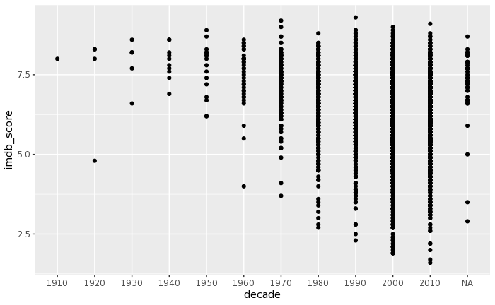

```r
final_chart_data %>%
  ggplot(aes(x = decade, y = imdb_score)) +
  geom_point()
```

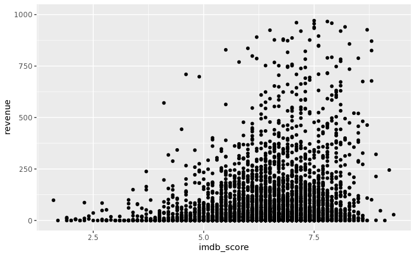

```r
final_chart_data %>%
  ggplot(aes(x = imdb_score, y = revenue)) +
  geom_point()+
  ylim(0, 1000)
```

Finally, here is the multivariable graphic that charts both revenue and release decade against the imdb score.

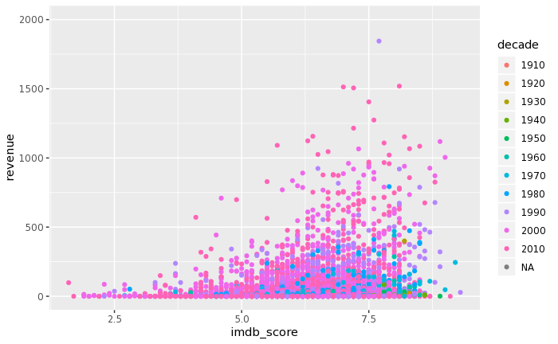

```r
final_chart_data %>%
  ggplot(aes(x = imdb_score, y= revenue))+
  geom_point(aes(color = decade))+
  ylim(0, 2000)
```

As we can see, there is a positive correlation between a movie’s revenue and its imdb score. Also it appears from the graphic that older movies, say <1960, seem to have higher imdb scores that newer movies.

Below is the same graphic but with the content_rating variable incorporated (and using the release decade variable as a facet)

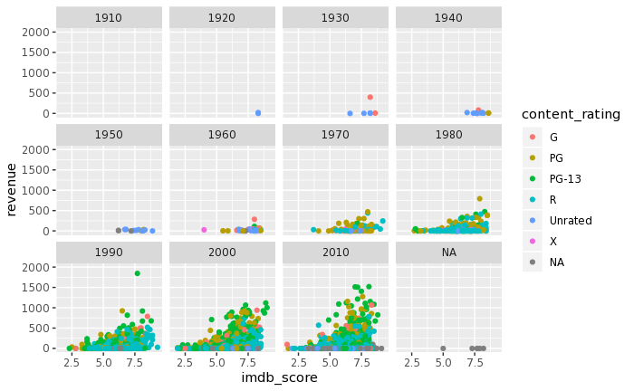

```r
final_chart_data %>%
  ggplot(aes(x = imdb_score, y= revenue))+
  geom_point(aes(color = content_rating))+
  ylim(0, 2000)+
  facet_wrap(~decade)
```

It is difficult to say if the content rating in conjuction with other variables play a significant role in the imdb score, but the conclusion made in the previous graphic seems to stand.

## Using a Decision Tree to Find Important Variables

Below is a regression tree we used that incoporates the revenue, content rating, and release decade to predict the imdb score.

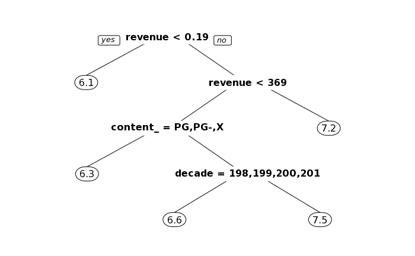

```r
model1 <- rpart(
  imdb_score ~ revenue + decade + content_rating,
  data = final_chart_data)
prp(model1)
```

The regression tree seems to have come to the same conclusions we made in our multivariable graphics, movies with larger revenues move towards higher imdb scores, as well as older movies (in the tree it is categorized as <1980).

## Findings/Conclusion

After exploring several variables in our movie dataset through summary views, graphics, and a machine learning model, we came to the conclusion that a movie’s revenue and the year/decade it was released in have the largest correlation with the movie’s imdb score. For revenue, the correlation was positive, so the more revenue the movie makes, the higher imdb score it tends to have. The correlation between release decade and imdb score, however, was negative, whichs means the older the movie, the higher the imdb score. While we have only found correlation between these variables, it is interesting to think about how factors like revenue and release date could influence and alter how well it is recieved/reviewed.